# Results and analyses

Tyler Peckenpaugh

April 7, 2019

This section reports various analyses of the recordings obtained.

# Prosody

## Breaks after PP1 and direct object

Across all experimental items, there was a break after the direct object in 72.4% of recordings and a break after PP1 in 84.5%.

For garden paths, there is an object break in 66.4% of items, while for non-garden paths only 77.6% had that break.

|  | Garden path | Non-garden path |
| --- | --- | --- |
| Declarative | 45.0 | 55.0 |
| Interrogative | 47.4 | 52.6 |

## ±Struggle

This section presents the counts of recordings where the reader struggled to maintain fluency. Table 1 shows the overall pattern across reading.

Table 1: Difficulty in reading by reading type

|  | Cold reading | Previewed reading |
| --- | --- | --- |
| Fluent | 459 | 483 |
| Struggle | 52 | 24 |

Table 2 shows the pattern across reading for just +GP items.

Table 2: Difficulty in reading by reading type for garden paths

|  | Cold reading | Previewed reading |
| --- | --- | --- |
| Fluent | 228 | 239 |
| Struggle | 29 | 13 |

Table 3: Logistic regression models of disfluency

|  | Full | No random effects | No interaction | Reading as only pred |
| --- | --- | --- | --- | --- |
| Intercept | -2.835 *** | -2.384 *** | -2.795 *** | -2.439 *** |
|  | (0.357) | (0.229) | (0.319) | (0.252) |
| +GP | 0.383 | 0.268 | 0.313 |  |
|  | (0.367) | (0.231) | (0.243) |  |
| +Q | 0.431 | 0.325 | 0.361 |  |
|  | (0.364) | (0.231) | (0.243) |  |
| +GP +Q | -0.126 |  |  |  |
|  | (0.489) |  |  |  |
| Previewed reading | -1.004 *** | -0.920 *** | -1.004 *** | -0.999 *** |
|  | (0.259) | (0.248) | (0.259) | (0.258) |
| Participant | 0.972 |  | 0.973 | 0.965 |
|  | (NA) |  | (NA) | (NA) |
| Item | 0.190 |  | 0.189 | 0.210 |
|  | (NA) |  | (NA) | (NA) |
| N | 1049 | 1049 | 1049 | 1049 |
| logLik | -266.262 | -283.457 | -266.295 | -268.214 |
| AIC | 546.525 | 574.915 | 544.591 | 544.428 |
| *** p < 0.001; ** p < 0.01; * p < 0.05. |  |  |  |  |

Cold vs. previewed reading is a statistically significant predictor in every case.

# Inter-reading time (IRT)

## IRT measurement

IRT was measured using a Python script and Google’s WebRTC Voice Activity Detection (VAD) over 44.1kHz WAV files downsampled to 8kHz via SOX. This VAD system uses Gaussian Mixture Models to make probabilistic decisions on whether a given audio frame is speech or noise (see (Falk and Chan 2006) for a complete explanation). Google’s implementation takes one paramater, which they call aggressiveness: a 4-tier setting for the level of confidence necessary to call a gvien frame speech. I call this “rejection rate”, where a higher rejection rate means that the model requires a high level of confidence before assuming a frame is speech, i.e. it is more likely to label something noise than speech. The implementation codes this setting as 0-3, where 0 is the most lenient (most likely to label a frame as speech) and 3 is the most stringent (most likely to label a frame as noise).

Google’s VAD API only accepts WAV files with sample rates that are a multiple of 8kHz. It ultimately downsamples all files to 8kHz, regardless of the input rate.

The recordngs vary in the volume of the speaker’s voice and the amount of background noise present. An algorothm was constructed to allow for the most stringent measurement of the least modified data that gave plausible measurements. Specifically, each file was measured using the highest possible rejection rate for the VAD algorithm and no modification of the file. If the timings detected were not plausible, the timings were re-measured with the same rejection rate, but after the recording had undergone a 200Hz high-pass filter (HPF). If that still failed, a 400Hz HPF was used. After a further failure, the rejection rate for the VAD was lowered, and the whole thing was tried again (0, 200Hz, 400Hz); and that process was itself repeated until the lowest possible rejection rate was tried of the four possible settings.

The exact algorithm is available on [github](https://gist.github.com/moui72/4ebc4eb8f69eb9fdb1cab160ce299675) (URL: bit.ly/2uMrcrG)

Of the 3097 recordings subjected to this treatment, 3067 resulted in plausible timings. For those that were successfull, the breakdown of HPF and rejection rate used is reported in Table 4. A further 9 were set by hand, resulting in a total of 3076 recordings.

Table 4: VAD rejection rate and HPF values

|  | No HPF | HPF at 200Hz | HPF at 400Hz |
| --- | --- | --- | --- |
| Lowest VAD rejection rate | 0 | 0 | 1 |
| … | 4 | 0 | 1 |
| … | 457 | 43 | 0 |
| Highest VAD rejection rate | 1386 | 1170 | 5 |

Plausible timings had to meet the following criteria:

1. An utterance length between 2s and 10s, where utterance timing is the longest contiguous span in the recording that VAD reports as phonation, with breaks in phonation of less than 1s not breaking contiguity.
2. A leading silence (“delay”) length of more than 120ms and less than 95% of the entire recording’s duration.
3. A trailing silence length of less than 95% of the entire recording’s duration.

Stimuli range from 18-22 syllables in length. If we assume a speeach rate of 3 to 7 syllables per second (Jacewicz, Fox, and Wei 2010) we would expect utterances between 2.5s and 7.3s. Conservative thresholds higher and lower than the expected were used, especially on the higher end to allow for any processing or fluency. Goldman-Eisler (1961) found that a large majority (82.5 to 87%) of pauses in fluent speech are less than 1s. Even a very fast human reaction time should not permit a delay shorter than 120ms.

# Distribution of IRT

The raw IRTs including fillers and before any outliers are trimmed are distributed as shown in Figure 1. Overall mean IRT of these data (n = 499), is 6.7s. The longest is 35.8s and the shortest 6ms. Median IRT is 6.1s.

Figure 1: Distribution of raw IRT

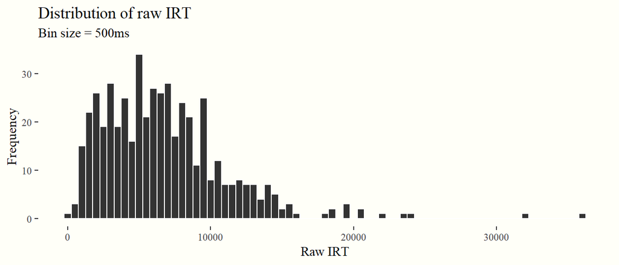

IRTs below 250ms (1) and above 25s (2) are (assumed to be implausible) omitted. Experimental data were then Winsorized by participant to bring data in the 5th and 95th percentile of data to the value at those tresholds. The resulting measure is referred to as wIRT and is distribued as shown in Figure 2 (n = 496). Overall mean for wIRT is 6.6s. The longest IRT is 22.8s and the shortest is 737ms. Median wIRT is 6.1s.

Figure 2: Distribution of wIRT

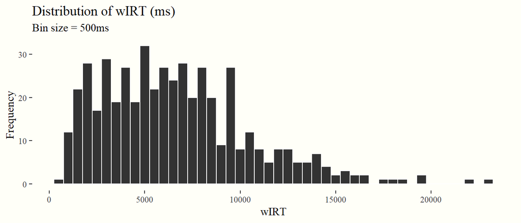

For the purposes of regression analysis, a common log transformation reduces the skew in the data. This distribution is seen in Figure 3.

Figure 3: Common log of wIRT

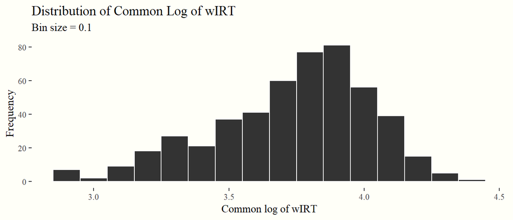

# Means by condition

Table 5 shows the mean wIRT by experimental condition. The top left cell represents the mean wIRT for the declaritive controls (“-Q -GP”). The bottom row shows the increase in IRT across the garden path condition.

Table 5: Means (s) by condition

| Condition | -Q | +Q |
| --- | --- | --- |
| -GP | 6.20 | 6.56 |
| +GP | 6.67 | 6.94 |
| Increase | 0.47 | 0.38 |

The difference in the effect of ±GP across ±Q is 0.09s. That is, the mean amount that IRT increased for a garden path declarative compared to a non-garden path declarative is 0.09s more than the amount that IRT increased for a garden path interrogative compared to a non-garden path interrogative.

Figure 4: Mean IRT by condition

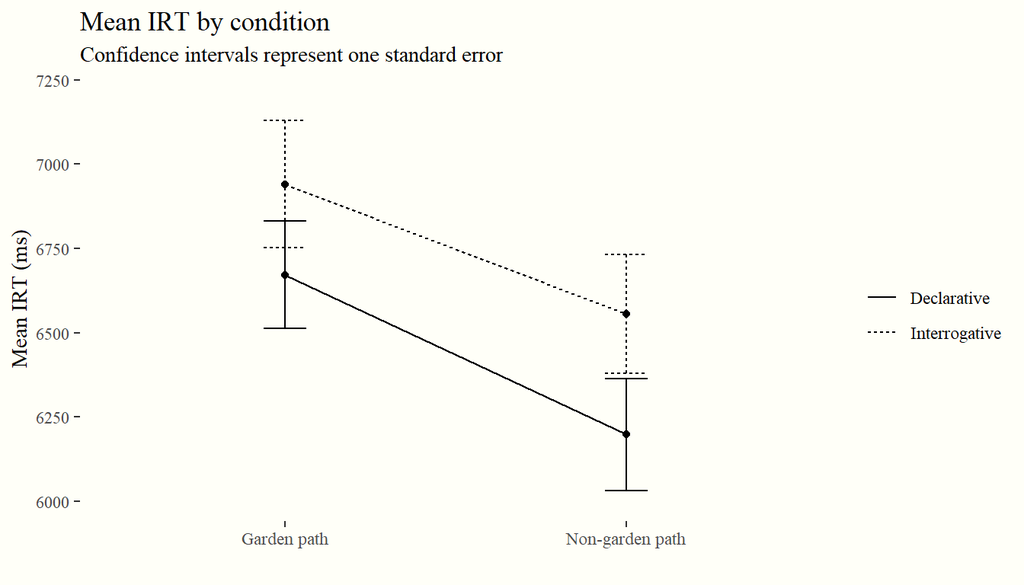

# Regression models of IRT

The models with random slopes for participant and item did not converge, so the tables in this section show models with no random slopes.

For the first model, fixed effects of ±GP and ±Q as well is the interaction between them were included, along with random effects of participant and item. The second model removes the interaction, but keeps both main effects.

Table 6: Models

|  | Full | No interaction | No random effects | No fixed effects |
| --- | --- | --- | --- | --- |
| +GP | 0.052 | 0.038 | 0.053 |  |
|  | (0.022) | (0.016) | (0.037) |  |
| +Q | 0.027 | 0.014 | 0.027 |  |
|  | (0.022) | (0.016) | (0.037) |  |
| +GP +Q | -0.027 |  | -0.034 |  |
|  | (0.031) |  | (0.052) |  |
| N | 496 | 496 | 496 | 496 |
| logLik | 112.218 | 111.835 | -88.252 | 108.415 |
| AIC | -210.435 | -211.670 | 186.505 | -208.829 |

A model with no fixed effects and one with no random effects were also run. The estimates from these models can be seen in table 6.

## Model comparisons

Several model comparisons were made, seen in the following tables.

Table 7: No fixed effects vs. full model

|  | Df | AIC | logLik | Χ<sup>2</sup> | Df(Χ) | p value |
| --- | --- | --- | --- | --- | --- | --- |
| No fixed effects model | 4 | -208.83 | 108.41 |  |  |  |
| Full model | 7 | -210.44 | 112.22 | 7.61 | 3 | 0.05 |

Table 8: No interaction vs. full model

|  | Df | AIC | logLik | Χ<sup>2</sup> | Df(Χ) | p value |
| --- | --- | --- | --- | --- | --- | --- |
| No interaction | 6 | -211.67 | 111.84 |  |  |  |
| Full | 7 | -210.44 | 112.22 | 0.77 | 1 | 0.38 |

The interaction between main effects, though, is not able to be confirmed (in fact, table 8 shows the non-interaction to be better, but not to a stastically significance degree).

Table 9: No random effects vs. full model

|  | Df | AIC | logLik | Χ<sup>2</sup> | Df(Χ) | p value |
| --- | --- | --- | --- | --- | --- | --- |
| No random effects | 5 | 186.50 | -88.25 |  |  |  |
| Full | 7 | -210.44 | 112.22 | 400.94 | 2 | 0.00 |

Table 9 shows that the random effects of participant and item improve the model in a stastically signifcant way.

# Delay comparison for cold vs. previewed readings

A comparison of the delay for cold readings compared with that of previewed readings can lend insight into the extent to which subjects followed task instructions.

“Delay” here is the amount of time after the start of a recording until the beginning of phonation of the target sentence. Cold readings are also called “reading 1”, while previewed readings are the same as “reading 2”. Implausible delays of >15s are excluded in the data shown here.

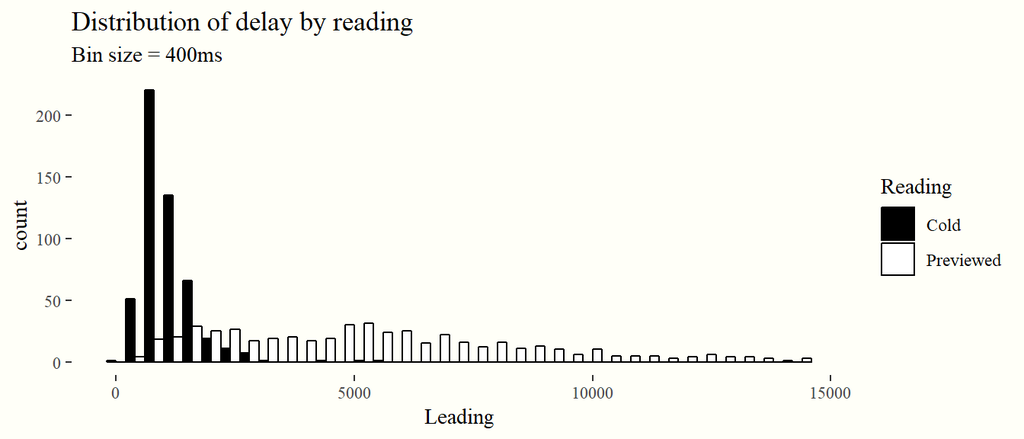

For cold readings, n = 514 and for previewed, n = 498.

## Difference in delay across paired readings

Overall, each recording pair (n = 497) has a mean difference in delay (DelDif = previewed delay - cold delay) of 4.3s (sd = 3.3s), with a minumum of -1.9s and a max of 13.4s. The median DelDif is 3.9s. The distribution DelDif is shown in Figure 5.

Figure 5: Distribution of DelDif

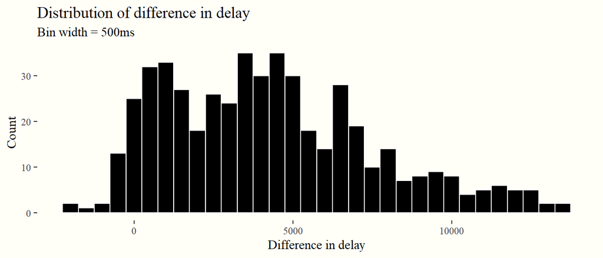

Table 10: Delay differences by participant

|  | Participant | Mean difference in delay (ms) |
| --- | --- | --- |
| 1 | 1 | 386 |
| 8 | 8 | 702 |
| 23 | 203 | 938 |
| 28 | 208 | 1183 |
| 29 | 209 | 1290 |
| 24 | 204 | 1502 |
| 22 | 201 | 1584 |
| 32 | 214 | 1604 |
| 26 | 206 | 2582 |
| 33 | 215 | 2814 |
| 20 | 21 | 2908 |
| 17 | 17 | 3139 |
| 31 | 212 | 3167 |
| 7 | 7 | 3682 |
| 9 | 9 | 3816 |
| 30 | 210 | 3908 |
| 21 | 22 | 3973 |
| 27 | 207 | 3988 |
| 12 | 12 | 4303 |
| 2 | 2 | 4369 |
| 4 | 4 | 4798 |
| 3 | 3 | 4841 |
| 11 | 11 | 4845 |
| 15 | 15 | 5961 |
| 10 | 10 | 6358 |
| 25 | 205 | 6858 |
| 14 | 14 | 7157 |
| 5 | 5 | 7838 |
| 13 | 13 | 8001 |
| 19 | 20 | 8685 |
| 16 | 16 | 9105 |
| 18 | 19 | 9537 |
| 6 | 6 | 10184 |

The distribution of the participants’ DelDifs can be found in Figure 6.

Figure 6: Mean difference in delay by participant

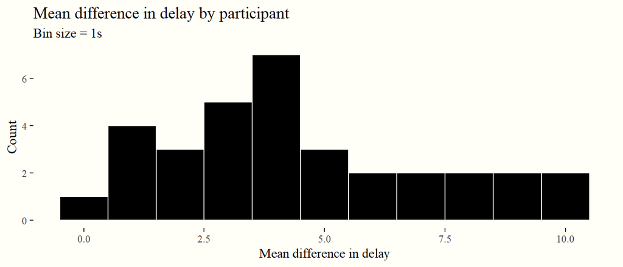

# Individual variation in IRT

Table 11: Mean wIRT (ms) by condition and participant

| Participant | -Q -GP | -Q +GP | +Q -GP | +Q +GP |
| --- | --- | --- | --- | --- |
| 12 | 5436.092 | 5236.717 | 6146.935 | 7347.062 |
| 17 | 3725.878 | 6283.250 | 5736.560 | 5128.127 |
| 1 | 2723.095 | 2764.875 | 3165.468 | 3061.438 |
| 10 | 9072.500 | 9416.155 | 8734.438 | 9630.157 |
| 11 | 8635.833 | 9030.440 | 5688.040 | 12075.837 |
| 13 | 10779.875 | 11638.595 | 9410.875 | 10931.093 |
| 14 | 7180.315 | 8851.722 | 8443.062 | 12052.435 |
| 15 | 9673.310 | 7771.158 | 9463.500 | 5764.438 |
| 16 | 12583.907 | 9725.440 | 9352.470 | 15201.440 |
| 19 | 8780.500 | 14237.875 | 17076.783 | 16161.185 |
| 2 | 6077.595 | 7088.435 | 4410.845 | 6398.435 |
| 20 | 9963.565 | 9211.125 | 12225.282 | 10081.030 |
| 201 | 1396.033 | 4249.562 | 2533.628 | 2206.812 |
| 203 | 1451.470 | 1501.438 | 1909.753 | 2472.343 |
| 204 | 3164.688 | 3173.847 | 2792.125 | 3586.500 |
| 205 | 6456.967 | 11925.468 | 7450.278 | 11345.407 |
| 206 | 3736.810 | 3707.875 | 3223.593 | 4985.440 |
| 207 | 5083.280 | 6428.315 | 6700.748 | 5199.312 |
| 208 | 2612.250 | 3449.810 | 2482.940 | 3263.970 |
| 209 | 2126.185 | 3625.500 | 2563.718 | 2967.907 |
| 21 | 5035.065 | 5748.627 | 6117.688 | 7204.748 |
| 210 | 5690.440 | 6105.592 | 6664.688 | 5098.160 |
| 212 | 4699.658 | 5192.250 | 4647.190 | 5065.035 |
| 214 | 3628.378 | 4118.707 | 5185.467 | 2026.030 |
| 215 | 4432.130 | 4132.312 | 5207.998 | 5075.938 |
| 22 | 5066.752 | 4134.533 | 5006.845 | 7975.283 |
| 3 | 5655.472 | 8400.845 | 6056.405 | 7267.347 |
| 4 | 7993.717 | 5457.905 | 10609.750 | 7010.720 |
| 5 | 13082.620 | 10694.565 | 9437.685 | 12188.125 |
| 6 | 12848.093 | 10828.407 | 13018.030 | 14695.872 |
| 7 | 5208.465 | 5864.283 | 6291.778 | 4918.595 |
| 9 | 6234.815 | 6632.685 | 6386.938 | 6484.312 |

Figure 7: Left tail of raw IRT distribution

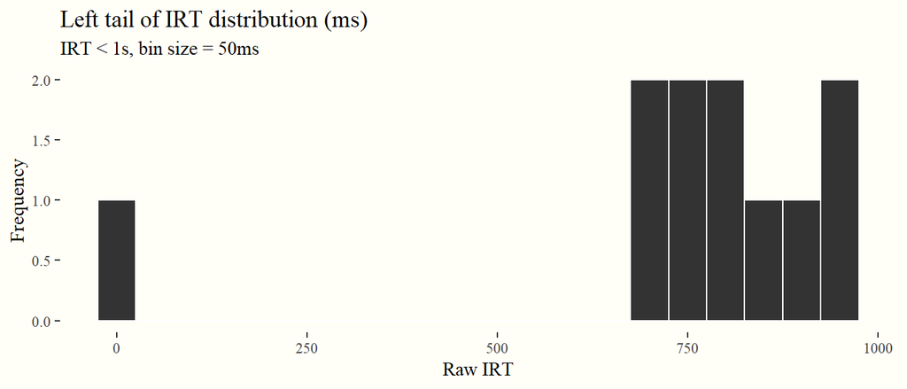

Figure 8: Right tail of raw IRT distribution

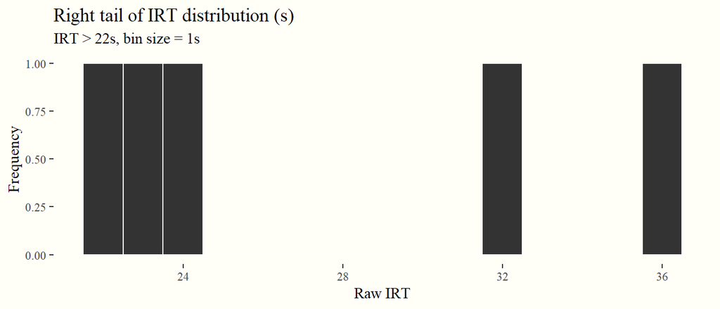

# Interrogative parsing cost

As previously discussed, interrogatives appear to have a computational processing cost when compared to interrogatives (cf. Lehiste 1973). The filler sentences in this study were designed so as to provide a diagnostic of the interrogative effect on IRT.

# References

Falk, Tiago H., and Wai-Yip Chan. 2006. “Nonintrusive Speech Quality Estimation Using Gaussian Mixture Models.” *IEEE Signal Processing Letters* 13 (2): 108–11.

Goldman-Eisler, Frieda. 1961. “The Distribution of Pause Durations in Speech.” *Language and Speech* 4 (4): 232–37.

Jacewicz, Ewa, Robert Allen Fox, and Lai Wei. 2010. “Between-Speaker and Within-Speaker Variation in Speech Tempo of American English.” *The Journal of the Acoustical Society of America* 128 (2): 839–50.

Lehiste, Ilse. 1973. “Phonetic Disambiguation of Syntactic Ambiguity.” *The Journal of the Acoustical Society of America* 53 (1): 380–80.